# Part II - Ford GoBike System Data

## by HAMZA ARIBI

## Investigation Overview

By understanding the caracteristics of our clients that help us to cible a people with same caracteristics to buy our services and also to build a specific marketing strategy for other. The distance and duration taken by major of riders is so important to suggest to them rides suits them and also build stations that hel much more them.

## Dataset Overview

The dadaset includes information about individual rides made in a bike-sharing system covering the greater San Francisco Bay area such as ride duration and gender and user type...

## (Visualization 1)

The graph is showing the number of clients by gender and user type because by understanding the caracteristics of our clients that help us to cible a people with same caracteristics to buy our services and also to build a specific marketing strategy for other.

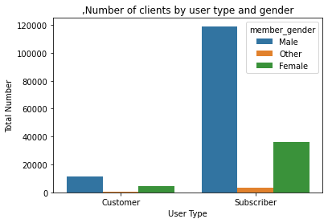

## (Visualization 2)

The graph is showing the ride duration by gender and birth year and that's help us to suggest the best ride for client considering his age and birth year.

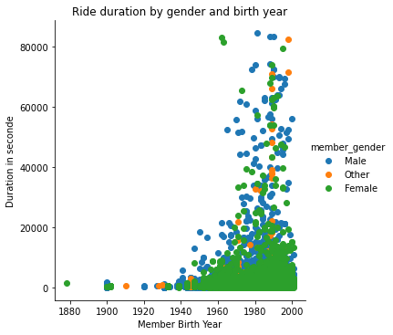

## (Visualization 3)

The graph is showing the ride distance by gender and birth year and that's help us to suggest the best ride for client considering his age and birth year.

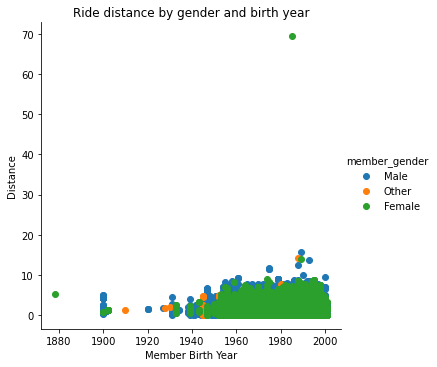